# Project: Investigate a Dataset - No-show appointments

- Introduction
- Data Wrangling
- Exploratory Data Analysis
- Conclusions

## Introduction

### Dataset Description

> This dataset collects information from 100k medical appointments in Brazil and is focused on the question of whether or not patients show up for their appointment. A number of characteristics about the patient are included in each row. ‘ScheduledDay’ tells us on what day the patient set up their appointment. ‘Neighborhood’ indicates the location of the hospital. ‘Scholarship’ indicates whether or not the patient is enrolled in Brasilian welfare program Bolsa Família(opens in a new tab).

### Question(s) for Analysis

> What factors are important for us to know in order to predict if a patient will show up for their scheduled appointment?
- Which demographic and health-related factors influence appointment show rates? Consider age, gender, alcoholism, handicap, and health conditions.
- Does appointment scheduling impact whether patients show up?

```python
import pandas as pd
import numpy as np
```

## Data Wrangling

### 🧹 Data Cleaning Decisions

```python
df = pd.read_csv("Database_No_show_appointments/noshowappointments-kagglev2-may-2016.csv")
df.head(10)
```

|  | PatientId | AppointmentID | Gender | ScheduledDay | AppointmentDay | Age | Neighbourhood | Scholarship | Hipertension | Diabetes | Alcoholism | Handcap | SMS_received | No-show |
| --- | --- | --- | --- | --- | --- | --- | --- | --- | --- | --- | --- | --- | --- | --- |
| 0 | 2.987250e+13 | 5642903 | F | 2016-04-29T18:38:08Z | 2016-04-29T00:00:00Z | 62 | JARDIM DA PENHA | 0 | 1 | 0 | 0 | 0 | 0 | No |
| 1 | 5.589978e+14 | 5642503 | M | 2016-04-29T16:08:27Z | 2016-04-29T00:00:00Z | 56 | JARDIM DA PENHA | 0 | 0 | 0 | 0 | 0 | 0 | No |
| 2 | 4.262962e+12 | 5642549 | F | 2016-04-29T16:19:04Z | 2016-04-29T00:00:00Z | 62 | MATA DA PRAIA | 0 | 0 | 0 | 0 | 0 | 0 | No |
| 3 | 8.679512e+11 | 5642828 | F | 2016-04-29T17:29:31Z | 2016-04-29T00:00:00Z | 8 | PONTAL DE CAMBURI | 0 | 0 | 0 | 0 | 0 | 0 | No |
| 4 | 8.841186e+12 | 5642494 | F | 2016-04-29T16:07:23Z | 2016-04-29T00:00:00Z | 56 | JARDIM DA PENHA | 0 | 1 | 1 | 0 | 0 | 0 | No |
| 5 | 9.598513e+13 | 5626772 | F | 2016-04-27T08:36:51Z | 2016-04-29T00:00:00Z | 76 | REPÚBLICA | 0 | 1 | 0 | 0 | 0 | 0 | No |
| 6 | 7.336882e+14 | 5630279 | F | 2016-04-27T15:05:12Z | 2016-04-29T00:00:00Z | 23 | GOIABEIRAS | 0 | 0 | 0 | 0 | 0 | 0 | Yes |
| 7 | 3.449833e+12 | 5630575 | F | 2016-04-27T15:39:58Z | 2016-04-29T00:00:00Z | 39 | GOIABEIRAS | 0 | 0 | 0 | 0 | 0 | 0 | Yes |
| 8 | 5.639473e+13 | 5638447 | F | 2016-04-29T08:02:16Z | 2016-04-29T00:00:00Z | 21 | ANDORINHAS | 0 | 0 | 0 | 0 | 0 | 0 | No |
| 9 | 7.812456e+13 | 5629123 | F | 2016-04-27T12:48:25Z | 2016-04-29T00:00:00Z | 19 | CONQUISTA | 0 | 0 | 0 | 0 | 0 | 0 | No |

```python
df.info() # change all column where the value is either 1 or 0 to int8 to free the memory
```

```
<class 'pandas.core.frame.DataFrame'>
RangeIndex: 110527 entries, 0 to 110526
Data columns (total 14 columns):
 #   Column          Non-Null Count   Dtype
---  ------          --------------   -----
 0   PatientId       110527 non-null  float64
 1   AppointmentID   110527 non-null  int64
 2   Gender          110527 non-null  object
 3   ScheduledDay    110527 non-null  object
 4   AppointmentDay  110527 non-null  object
 5   Age             110527 non-null  int64
 6   Neighbourhood   110527 non-null  object
 7   Scholarship     110527 non-null  int64
 8   Hipertension    110527 non-null  int64
 9   Diabetes        110527 non-null  int64
 10  Alcoholism      110527 non-null  int64
 11  Handcap         110527 non-null  int64
 12  SMS_received    110527 non-null  int64
 13  No-show         110527 non-null  object
dtypes: float64(1), int64(8), object(5)
memory usage: 11.8+ MB
```

```python
df.shape
```

```
(110527, 14)
```

```python
# Checking the binary values - columns
print(df["Scholarship"].unique())
print(df["Diabetes"].unique())
print(df["Handcap"].unique()) ## Since Handcap is not binary column I will map all values > 0 to 1
print(df["Alcoholism"].unique())
print(df["Hipertension"].unique())
print(df["SMS_received"].unique())
```

```
[0 1]
[0 1]
[0 1 2 3 4]
[0 1]
[1 0]
[0 1]
```

```python
df["Handcap"].unique()
```

```
array([0, 1, 2, 3, 4])
```

```python
df["Handcap"].value_counts() # to see the frequency of values 2,3,4
```

```
0    108286
1      2042
2       183
3        13
4         3
Name: Handcap, dtype: int64
```

### Data Cleaning

> **Binary Columns Optimization**: the columns were converted to int8 to reduce memory usage

```python
binary_cols = ['Scholarship', 'Hipertension', 'Diabetes', 'Alcoholism', 'SMS_received','Handcap']
df[binary_cols] = df[binary_cols].astype("int8") # Data optimization step - changing all binary value - columns to type int8
```

> **Handcap Column Inconsistency**:  
> According to the dataset documentation, the `Handcap` column is intended to be binary, indicating whether the patient is handicapped (`0` = no, `1` = yes).  
> However, we observed rare occurrences of values such as `2`, `3`, and `4`, which are not documented and represent a very small portion of the dataset.  
> Given their low frequency and the binary nature described in the documentation, it is likely these values were introduced due to data entry errors or mislabeling.  
> To reflect the original binary intention, we normalized the column by mapping all values greater than `0` to `1`.

```python
df.rename(columns={"Handcap": "Handicap"}, inplace=True) # Additional step to improve clarity of our analysis
```

```python
df["Handicap"] = df["Handicap"].apply(lambda x: 1 if x > 0 else 0) # Assigning 1 to all values greater that 0 or 1
df["Handicap"] = df["Handicap"].astype("int8")
# Drop rows with negative age
df = df[df["Age"] >= 0]
```

```python
df["Handicap"].value_counts()
```

```
0    108285
1      2241
Name: Handicap, dtype: int64
```

> **Date Formatting**: The `scheduled_day` and `appointment_day` columns were initially stored as strings (`object` type). They will be converted to proper datetime format using `pd.to_datetime()` for accurate time-based calculations.

```python
date= ["ScheduledDay","AppointmentDay"] # Cleaning Date Columns
for n in date:
 df[n] = pd.to_datetime(df[n])
 df[n] = df[n].dt.date

df.head(10)
```

|  | PatientId | AppointmentID | Gender | ScheduledDay | AppointmentDay | Age | Neighbourhood | Scholarship | Hipertension | Diabetes | Alcoholism | Handicap | SMS_received | No-show |
| --- | --- | --- | --- | --- | --- | --- | --- | --- | --- | --- | --- | --- | --- | --- |
| 0 | 2.987250e+13 | 5642903 | F | 2016-04-29 | 2016-04-29 | 62 | JARDIM DA PENHA | 0 | 1 | 0 | 0 | 0 | 0 | No |
| 1 | 5.589978e+14 | 5642503 | M | 2016-04-29 | 2016-04-29 | 56 | JARDIM DA PENHA | 0 | 0 | 0 | 0 | 0 | 0 | No |
| 2 | 4.262962e+12 | 5642549 | F | 2016-04-29 | 2016-04-29 | 62 | MATA DA PRAIA | 0 | 0 | 0 | 0 | 0 | 0 | No |
| 3 | 8.679512e+11 | 5642828 | F | 2016-04-29 | 2016-04-29 | 8 | PONTAL DE CAMBURI | 0 | 0 | 0 | 0 | 0 | 0 | No |
| 4 | 8.841186e+12 | 5642494 | F | 2016-04-29 | 2016-04-29 | 56 | JARDIM DA PENHA | 0 | 1 | 1 | 0 | 0 | 0 | No |
| 5 | 9.598513e+13 | 5626772 | F | 2016-04-27 | 2016-04-29 | 76 | REPÚBLICA | 0 | 1 | 0 | 0 | 0 | 0 | No |
| 6 | 7.336882e+14 | 5630279 | F | 2016-04-27 | 2016-04-29 | 23 | GOIABEIRAS | 0 | 0 | 0 | 0 | 0 | 0 | Yes |
| 7 | 3.449833e+12 | 5630575 | F | 2016-04-27 | 2016-04-29 | 39 | GOIABEIRAS | 0 | 0 | 0 | 0 | 0 | 0 | Yes |
| 8 | 5.639473e+13 | 5638447 | F | 2016-04-29 | 2016-04-29 | 21 | ANDORINHAS | 0 | 0 | 0 | 0 | 0 | 0 | No |
| 9 | 7.812456e+13 | 5629123 | F | 2016-04-27 | 2016-04-29 | 19 | CONQUISTA | 0 | 0 | 0 | 0 | 0 | 0 | No |

```python
df.duplicated().sum() # Check for Duplicates
```

```
0
```

```python
df.rename(columns={"No-show": "No_show"}, inplace=True) # Renaming column
df.head(5)
```

[output not shown]

> Since the column "No_Show" only contains two unique values (No or Yes), using the category data type can save memory and improve performance, especially when dealing with large datasets.

```python
df["No_show"] = df["No_show"].astype("category")  # changing object type column to category to save memory
```

```python
df.info()
df.memory_usage(deep=True)
```

```
<class 'pandas.core.frame.DataFrame'>
Int64Index: 110526 entries, 0 to 110526
Data columns (total 14 columns):
 #   Column          Non-Null Count   Dtype
---  ------          --------------   -----
 0   PatientId       110526 non-null  float64
 1   AppointmentID   110526 non-null  int64
 2   Gender          110526 non-null  object
 3   ScheduledDay    110526 non-null  object
 4   AppointmentDay  110526 non-null  object
 5   Age             110526 non-null  int64
 6   Neighbourhood   110526 non-null  object
 7   Scholarship     110526 non-null  int8
 8   Hypertension    110526 non-null  int8
 9   Diabetes        110526 non-null  int8
 10  Alcoholism      110526 non-null  int8
 11  Handicap        110526 non-null  int8
 12  SMS_received    110526 non-null  int8
 13  No_show         110526 non-null  category
dtypes: category(1), float64(1), int64(2), int8(6), object(4)
memory usage: 7.5+ MB
```

```
Index              884208
PatientId          884208
AppointmentID      884208
Gender            6410508
ScheduledDay      4421040
AppointmentDay    4421040
Age                884208
Neighbourhood     9096250
Scholarship        110526
Hypertension       110526
Diabetes           110526
Alcoholism         110526
Handicap           110526
SMS_received       110526
No_show            110753
dtype: int64
```

### Conclusion on Data Optimization

As part of our data cleaning and optimization process, we have successfully reduced the memory usage of the dataset by adjusting the data types of specific columns. Key improvements include:

#### Result:

- **Before Optimization**: 11.8 MB
- **After Optimization**: 7.5 MB

These optimizations help improve the efficiency of our analysis and will enable better performance as we work with larger datasets.

## Exploratory Data Analysis

## Research Questions for Analysis

### Research Question 1- Which demographic and health-related factors influence appointment show rates?

> To explore which personal factors may influence whether a patient attends their appointment, we focused on the following columns from the dataset:
- **Age**: A continuous variable representing the patient’s age.
- **Diabetes**: A binary indicator of whether the patient has diabetes (1 = Yes, 0 = No).
- **Alcoholism**: A binary indicator of whether the patient is registered as an alcoholic (1 = Yes, 0 = No).

### Age and Appointment Attendance

> The average age of patients who **showed up** for their appointments was approximately **37.8 years**, while those who **did not show up** averaged around **34.3 years**. This suggests that **younger patients are slightly more likely to miss their appointments** than older patients.

```python
# Drop missing values
age_data = df[['Age', 'No_show']].dropna()

# Calculate age distribution for patients who showed up (No) and did not show up (Yes)
no_show_no = age_data[age_data['No_show'] == 'No']['Age']
no_show_yes = age_data[age_data['No_show'] == 'Yes']['Age']

# Print the average age for each group
print("Average age for patients who showed up (No):", np.mean(no_show_no))
print("Average age for patients who did not show up (Yes):", np.mean(no_show_yes))
```

```
Average age for patients who showed up (No): 37.790504154999034
Average age for patients who did not show up (Yes): 34.31766656212196
```

### Diabetes and Appointment Attendance

> Among patients who **showed up** for their appointments, approximately **7.38%** had diabetes.  
> Among patients who **did not show up**, about **6.41%** had diabetes. This indicates that **diabetic patients are slightly more likely to attend their appointments** compared to non-diabetic patients.  
> However, the difference is relatively small and may require statistical testing to confirm significance.

```python
df.groupby("No_show")["Diabetes"].mean()
```

```
No_show
No     0.073838
Yes    0.064071
Name: Diabetes, dtype: float64
```

### Alcoholism and Appointment Attendance

> The proportion of alcoholic patients is very similar between those who **showed up** (3.04%) and those who **did not show up** (3.03%). This suggests that **alcoholism does not appear to have a significant effect** on whether a patient attends their appointment.

```python
df.groupby("No_show")["Alcoholism"].mean()
```

```
No_show
No     0.030417
Yes    0.030333
Name: Alcoholism, dtype: float64
```

```python
df.groupby("No_show")["Hypertension"].mean()
```

```
No_show
No     0.204394
Yes    0.169004
Name: Hypertension, dtype: float64
```

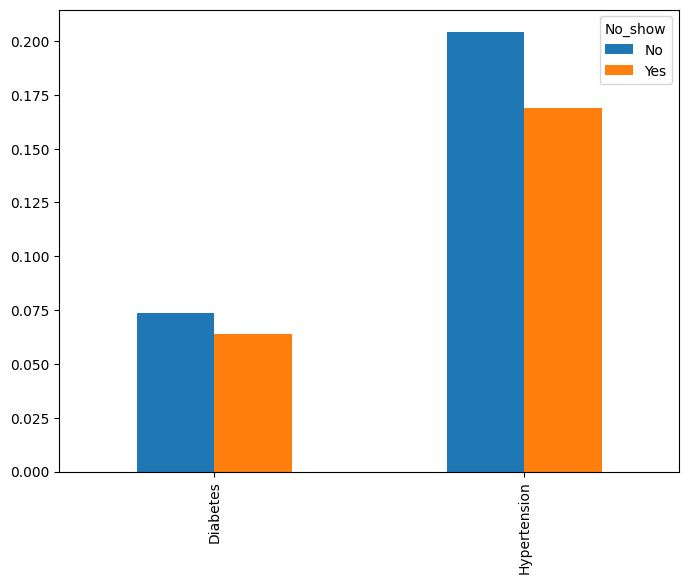

```python
proportions = df.groupby('No_show')[['Diabetes', 'Hypertension']].mean()
proportions.T.plot(kind='bar', figsize=(8,6))

# This calculates the average proportion of patients with Hypertension and Diabetes for each 'No_show' group.
# Comparing these conditions helps assess whether one condition (e.g., Diabetes) is associated with a higher likelihood of attending appointments than the other (e.g., Hypertension).
# A higher value in the 'No' group would suggest that the condition is more prevalent among those who showed up, and vice versa.
```

## Analysis of No-show Rates for Hypertension and Diabetes

In this analysis, we explore how the health conditions **Hypertension** and **Diabetes** influence appointment no-show rates. The comparison between these two conditions needs to account for their different prevalences in the dataset to ensure a fair analysis.

### Key Observations:

- **Hypertension** is more prevalent in the dataset, meaning that a higher raw no-show rate could be due to the larger number of hypertensive patients.
- **Diabetes**, being less common, might have a different no-show rate that is less influenced by the number of patients.

To make the comparison fair, we will normalize the no-show rates for each condition by calculating the proportion of no-shows **within each condition group**.

### Steps:

1. Calculate the **no-show rate** for patients with **Hypertension**.
2. Calculate the **no-show rate** for patients with **Diabetes**.
3. Compare the relative no-show rates between the two conditions.

Let's proceed with the analysis in the next code cell.

```python
# Calculate the proportion of No-show for each condition, normalized by the total number of patients with that condition
hypertension_no_show_rate = df[df['Hypertension'] == 1].groupby('No_show').size() / df[df['Hypertension'] == 1].shape[0]
diabetes_no_show_rate = df[df['Diabetes'] == 1].groupby('No_show').size() / df[df['Diabetes'] == 1].shape[0]

# Display the results
print("Hypertension No-show Rate (normalized):")
print(hypertension_no_show_rate)
print("\nDiabetes No-show Rate (normalized):")
print(diabetes_no_show_rate)
```

```
Hypertension No-show Rate (normalized):
No_show
No     0.82698
Yes    0.17302
dtype: float64

Diabetes No-show Rate (normalized):
No_show
No     0.819967
Yes    0.180033
dtype: float64
```

Conclusion : Both Hypertension and Diabetes are chronic health conditions that likely involve regular medical visits.

Patients with either condition may be more motivated to attend appointments due to the need for ongoing monitoring and treatment, which could explain why both groups have similar no-show rates (around 82% showing up, 18% missing appointments).

### Research Question 2 - Does appointment scheduling impact whether patients show up?

```python
df["Wait_time"] = (df["AppointmentDay"] - df["ScheduledDay"]).dt.days
df.head()
```

|  | PatientId | AppointmentID | Gender | ScheduledDay | AppointmentDay | Age | Neighbourhood | Scholarship | Hypertension | Diabetes | Alcoholism | Handicap | SMS_received | No_show | Wait_time |
| --- | --- | --- | --- | --- | --- | --- | --- | --- | --- | --- | --- | --- | --- | --- | --- |
| 0 | 2.987250e+13 | 5642903 | F | 2016-04-29 | 2016-04-29 | 62 | JARDIM DA PENHA | 0 | 1 | 0 | 0 | 0 | 0 | No | 0 |
| 1 | 5.589978e+14 | 5642503 | M | 2016-04-29 | 2016-04-29 | 56 | JARDIM DA PENHA | 0 | 0 | 0 | 0 | 0 | 0 | No | 0 |
| 2 | 4.262962e+12 | 5642549 | F | 2016-04-29 | 2016-04-29 | 62 | MATA DA PRAIA | 0 | 0 | 0 | 0 | 0 | 0 | No | 0 |
| 3 | 8.679512e+11 | 5642828 | F | 2016-04-29 | 2016-04-29 | 8 | PONTAL DE CAMBURI | 0 | 0 | 0 | 0 | 0 | 0 | No | 0 |
| 4 | 8.841186e+12 | 5642494 | F | 2016-04-29 | 2016-04-29 | 56 | JARDIM DA PENHA | 0 | 1 | 1 | 0 | 0 | 0 | No | 0 |

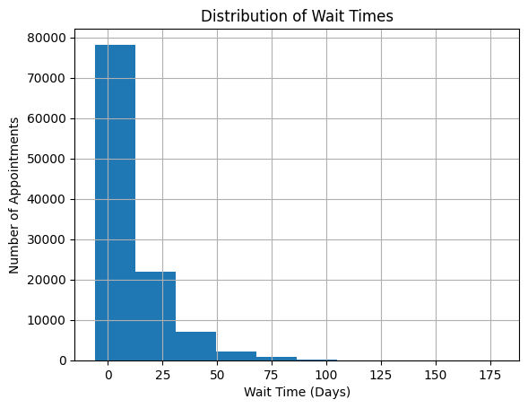

```python
# Calculate the Wait_time column
df["Wait_time"] = (df["AppointmentDay"] - df["ScheduledDay"]).dt.days

# Plot the histogram of the Wait_time column with axis labels
ax = df['Wait_time'].hist(bins=10)
ax.set_xlabel('Wait Time (Days)')  # X-axis label
ax.set_ylabel('Number of Appointments')  # Y-axis label
ax.set_title('Distribution of Wait Times')  # Title of the plot
```

> This suggests that longer wait times between scheduling and appointment are associated with a higher chance of not showing up. Reducing the time between scheduling and the actual appointment could potentially increase attendance rates.

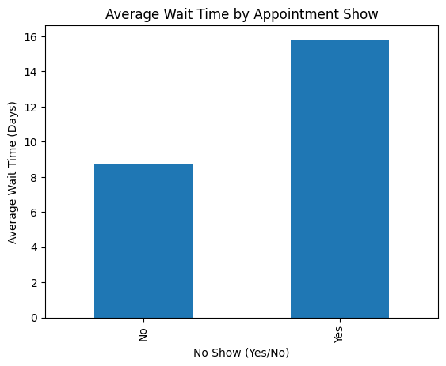

```python
# Calculate the average Wait_time grouped by No_show
average_wait_time = df.groupby("No_show")["Wait_time"].mean()

# Plot the average wait times for both groups
average_wait_time.plot(kind='bar', xlabel='No Show (Yes/No)', ylabel='Average Wait Time (Days)', title='Average Wait Time by Appointment Show')
```

### SMS received - 1D Exploration

```python
# Frequency distribution of SMS_received (1 for received, 0 for not received)
sms_received_counts = df['SMS_received'].value_counts()
print(sms_received_counts)
```

```
0    75044
1    35482
Name: SMS_received, dtype: int64
```

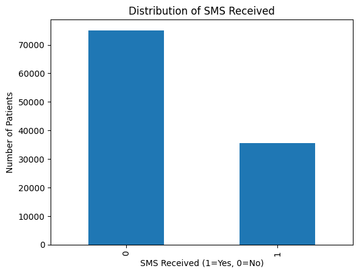

```python
# Plot the distribution of SMS_received (1 for received, 0 for not received)
sms_received_counts.plot(kind='bar', xlabel='SMS Received (1=Yes, 0=No)', ylabel='Number of Patients', title='Distribution of SMS Received')
```

# Conclusion

### 2. Appointment Scheduling Impact:

- **Wait Time:** Patients who had longer waiting times between scheduling and the actual appointment were less likely to show up. On average, patients who missed their appointments had longer wait times.

### Limitations:

- **Ambiguity in 'No-show' Label.** The No-show column contains 'Yes' for people who didn't show up — which is counterintuitive and can lead to misinterpretation or mistakes in analysis.
- **Limited SMS Reminder Context.** We only know whether an SMS was received (SMS_received = 1 or 0).There’s no information about: When the SMS was sent/ If it was actually read/ The message content or frequency. This makes it difficult to evaluate the true effectiveness of the reminder system.
- **Neighborhood as a Categorical Variable.** The Neighbourhood column is treated categorically, but: We don’t have geospatial data (e.g., distance to clinic, transportation access).This limits the depth of our analysis about physical accessibility.
- **Imbalanced Classes.** The dataset is imbalanced with many more “show” than “no-show” cases. This can bias some statistical interpretations unless properly accounted for.

```python
# Running this cell will execute a bash command to convert this notebook to an .html file
!python -m nbconvert --to html Investigate_a_Dataset.ipynb
```

```
[NbConvertApp] Converting notebook Investigate_a_Dataset.ipynb to html
[NbConvertApp] WARNING | Alternative text is missing on 1 image(s).
[NbConvertApp] Writing 369647 bytes to Investigate_a_Dataset.html
```